# EM算法模拟

## 准备工作

首先，加载必要的R包和源代码文件

```r
# 缓存代码运行结果
knitr::opts_chunk$set(cache = TRUE)

library(Rcpp)
library(ggplot2)
library(pscl)
setwd("/Users/guosa/Desktop/日常/科研/负二项分布/code/NB-EM-Algorithm/Simulation")

sourceCpp("../Simulation/Samples/Generate_Samples.cpp") # 生成样本

sourceCpp("../Simulation/NB/SimulateNB.cpp") # 估计负二项分布

sourceCpp("../Simulation/MixNB/SimulateMixNB.cpp") # 估计混合负二项分布
source("../Simulation/MixNB/VisualMixNB.r")
sourceCpp("../Simulation/ZINB/SimulateZINB.cpp") #估计零膨胀负二项分布

# 设置随机数种子
set.seed(123)
```

## 负二项分布模型

```r
# 定义参数
prob_values = seq(0.2, 0.8, 0.2) # 定义概率参数
size_values = seq(1, 9, 2) # 定义离散参数
# 执行模拟
res_NB = SimulateNBs(prob_values, size_values, 20, 2000)
res_NB
```

```
##    prob size  avg_prob     sd_prob  avg_size    sd_size avg_t      sd_t
## 1   0.2    1 0.2008606 0.010054541 0.9997919 0.04402773  9.00  2.809757
## 2   0.2    3 0.1984889 0.006663385 2.9871694 0.13184616 24.20  6.469361
## 3   0.2    5 0.1999531 0.006876225 4.9868297 0.19552486 30.30 17.287355
## 4   0.2    7 0.1980306 0.004492471 6.9243210 0.19106573 47.55 14.605244
## 5   0.2    9 0.2002235 0.006799688 8.9935788 0.34062271 54.35 23.899516
## 6   0.4    1 0.4037201 0.017692968 1.0150411 0.07394371  8.35  2.254236
## 7   0.4    3 0.4008155 0.014304319 3.0198572 0.18562431 18.75  6.239728
## 8   0.4    5 0.3970126 0.012969821 4.9224001 0.29498126 29.05  6.684428
## 9   0.4    7 0.4009811 0.009304374 7.0109633 0.29007090 34.45 13.755286
## 10  0.4    9 0.4038458 0.008292844 9.1741189 0.29587285 44.70 13.776792
## 11  0.6    1 0.6037684 0.026788097 1.0262818 0.11470029  8.10  2.531902
## 12  0.6    3 0.6015769 0.021630789 3.0087712 0.26516946 16.40  6.090545
## 13  0.6    5 0.6048129 0.021086124 5.1399929 0.46111918 25.75  6.687577
## 14  0.6    7 0.6103756 0.022446786 7.3468392 0.71851986 36.05 12.700912
## 15  0.6    9 0.6007954 0.015704382 9.0742843 0.59984949 37.80 14.021037
## 16  0.8    1 0.8297409 0.030155339 1.2344172 0.24128232  9.95  1.669384
## 17  0.8    3 0.8004470 0.032236241 3.0621697 0.59738739 18.15  5.323978
## 18  0.8    5 0.7981765 0.021496248 5.0318237 0.71077344 24.10  8.187924
## 19  0.8    7 0.7956168 0.023620361 6.9516552 0.92088290 33.10  7.217668
## 20  0.8    9 0.8031810 0.022666929 9.3784093 1.44336628 40.00 12.473129
```

结果分析

模拟数据：

概率参数从0.2到0.8以0.2为间隔，以及离散参数从1到9以2为间隔，每个参数配置下生成20组样本，每个样本包含2000个数据点

模拟结果:

参数估计精度：通过比较avg_prob和avg_size与其各自的理论值，可以看出EM-NB算法能够较准确地估计负二项分布的参数，表明算法对于不同的概率和分布离散度具有良好的适应性和准确性；

收敛性能：观察avg_t和sd_t指标发现，算法的收敛速度受到概率和离散参数的影响。特别是在低概率和高离散度的情况下，算法需要更多的迭代次数来达到收敛；

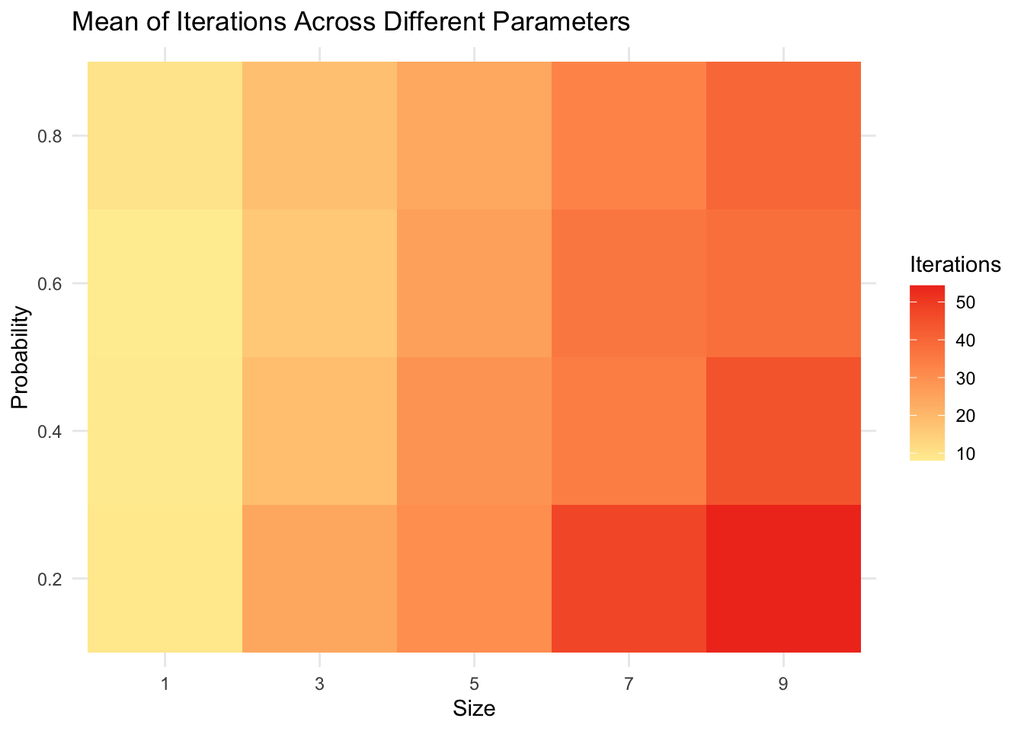

```r
ggplot(res_NB, aes(x = as.factor(size), y = as.factor(prob))) +
  geom_tile(aes(fill = avg_t)) +
  scale_fill_gradient(low = "#ffeda0", high = "#f03b20") +
  labs(x = "Size", y = "Probability", fill = "Iterations") +
  theme_minimal() +
  ggtitle("Mean of Iterations Across Different Parameters")
```

## 混合负二项分布模型

### 两个总体

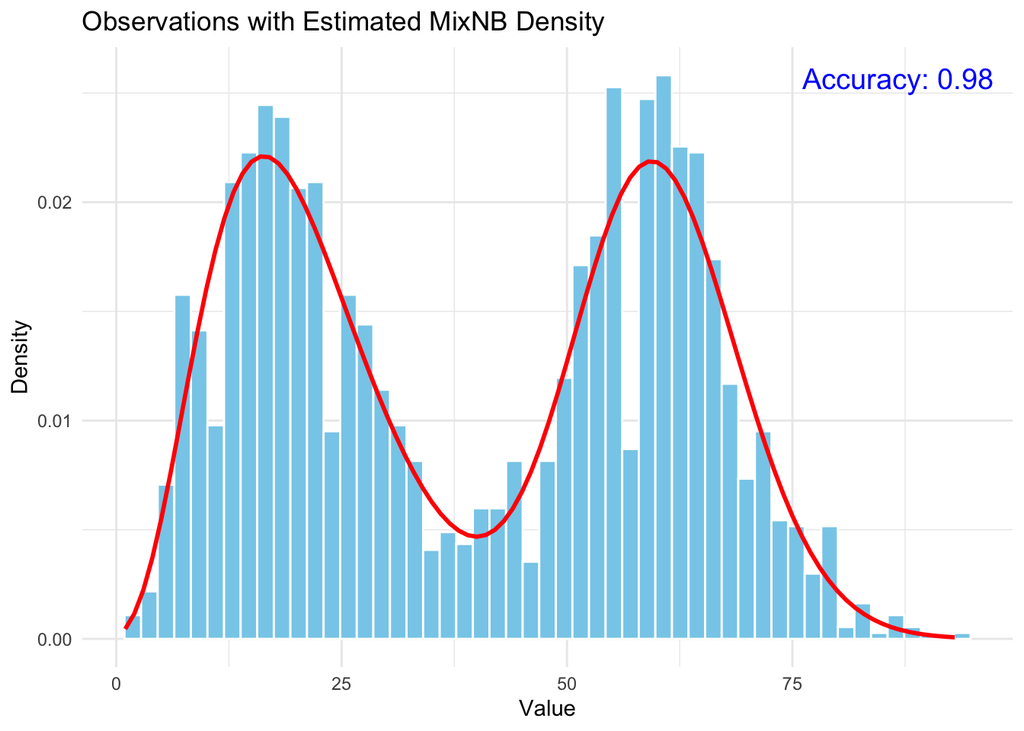

```r
weights <- c(0.5, 0.5)
means <- c(20, 60)
vars <- c(80, 80)
probs <- means / vars
sizes <- means^2 / (vars - means)

# 生成数据并进行分组
res <- SimulateMixNB(probs, sizes, weights, 2000)

# 对比图
plotHistDensity(res$observations, res$estimation, res$accuracy)
```

### 三个总体

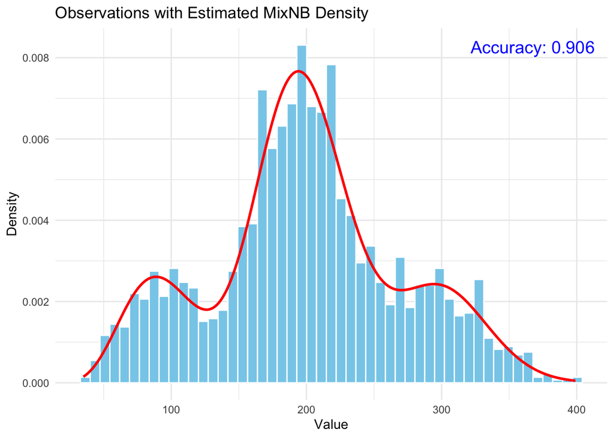

```r
# 模拟参数
weights <- c(0.2, 0.6, 0.2)
means <- c(100, 200, 300)
vars <- c(1000, 1000, 1000)
probs <- means / vars
sizes <- means^2 / (vars - means)

# 生成数据并进行分组
res <- SimulateMixNB(probs, sizes, weights, 2000)

# 对比图
plotHistDensity(res$observations, res$estimation, res$accuracy)
```

```r
# confusion matrix
conf_matrix <- confusionMatrix(as.factor(res$predicted_labels), as.factor(res$true_labels))
conf_matrix
```

```
## Confusion Matrix and Statistics
##
##           Reference
## Prediction    1    2    3
##          1  356   49    0
##          2   43 1089   23
##          3    0   73  367
##
## Overall Statistics
##
##                Accuracy : 0.906
##                  95% CI : (0.8924, 0.9184)
##     No Information Rate : 0.6055
##     P-Value [Acc > NIR] : < 2.2e-16
##
##                   Kappa : 0.8342
##
##  Mcnemar's Test P-Value : NA
##
## Statistics by Class:
##
##                      Class: 1 Class: 2 Class: 3
## Sensitivity            0.8922   0.8993   0.9410
## Specificity            0.9694   0.9163   0.9547
## Pos Pred Value         0.8790   0.9429   0.8341
## Neg Pred Value         0.9730   0.8556   0.9853
## Prevalence             0.1995   0.6055   0.1950
## Detection Rate         0.1780   0.5445   0.1835
## Detection Prevalence   0.2025   0.5775   0.2200
## Balanced Accuracy      0.9308   0.9078   0.9478
```

### 算法稳定性分析

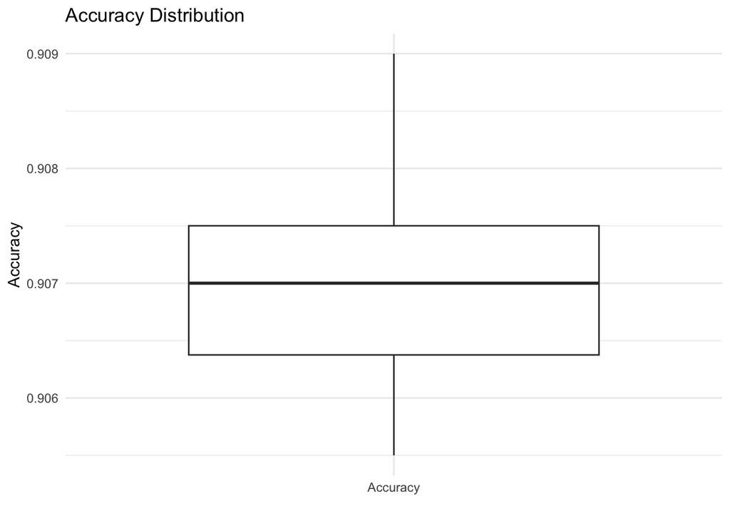

```r
# 运行100次，观察准确率与迭代次数
data <- SimulateMixNBs(probs, sizes, weights, 100, 2000)

df_accuracy <- data.frame(Value = data$accuracy, Type = "Accuracy")
df_iterations <- data.frame(Value = data$iterations, Type = "Iterations")

# accuracy箱线图
ggplot(df_accuracy, aes(x = Type, y = Value)) +
    geom_boxplot() +
    theme_minimal() +
    labs(title = "Accuracy Distribution", x = "", y = "Accuracy")
```

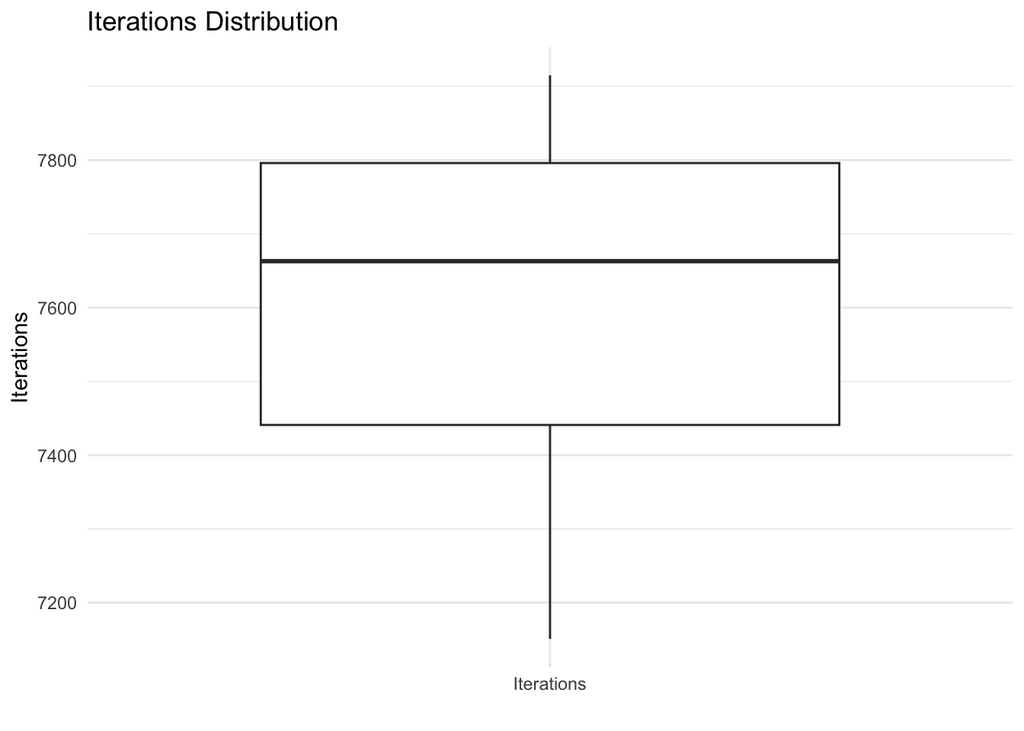

```r
# iterations箱线图
ggplot(df_iterations, aes(x = Type, y = Value)) +
    geom_boxplot() +
    theme_minimal() +
    labs(title = "Iterations Distribution", x = "", y = "Iterations")
```

## 零膨胀负二项分布模型

### 生成模拟数据算法运行结果

```r
prob_values <- seq(0.2, 0.6, 0.2)
size_values <- seq(6, 10, 2)
zero_values <- seq(0.2, 0.6, 0.2)

res_ZINB <- SimulateZINBs(prob_values, size_values, zero_values, 20, 2000)
res_ZINB
```

```
##    prob size zero  avg_prob     sd_prob  avg_size   sd_size  avg_zero
## 1   0.2    6  0.2 0.1976455 0.006544177  5.906899 0.2424127 0.2020524
## 2   0.2    6  0.4 0.2021797 0.009963108  6.079146 0.3510271 0.4003462
## 3   0.2    6  0.6 0.1978030 0.009673378  5.960559 0.3485814 0.6025548
## 4   0.2    8  0.2 0.2008377 0.006289190  8.045326 0.2711458 0.1983233
## 5   0.2    8  0.4 0.2036633 0.007215965  8.184413 0.3405845 0.4003240
## 6   0.2    8  0.6 0.2011967 0.010687783  8.075321 0.5185054 0.6031992
## 7   0.2   10  0.2 0.1992604 0.007236198  9.927565 0.4605409 0.2002749
## 8   0.2   10  0.4 0.2007077 0.009465299 10.058554 0.5584082 0.3987750
## 9   0.2   10  0.6 0.2018772 0.009919092 10.146702 0.6488324 0.5991250
## 10  0.4    6  0.2 0.4068587 0.015147848  6.210497 0.3637400 0.2006963
## 11  0.4    6  0.4 0.4067943 0.019774207  6.202453 0.4960093 0.3986970
## 12  0.4    6  0.6 0.4006257 0.016338874  6.058471 0.3880528 0.5980549
## 13  0.4    8  0.2 0.4065941 0.015436515  8.264234 0.5266038 0.1995422
## 14  0.4    8  0.4 0.4079575 0.020753118  8.276714 0.7206078 0.3960117
```

[output cut: 41 more lines]

### EM与BFGS比较

```r
# EM与BFGS比较
compare <- function(prob, size, zero, sample_size) {
    sample <- unlist(SamplesZINB(prob, size, zero, 1, sample_size))

    res_BFGS <- zeroinfl(count ~ 1, data = data.frame(count = sample), dist = "negbin")
    size_BFGS <- res_BFGS$theta
    mu_BFGS <- exp(res_BFGS$coefficients$count)
    zero_BFGS <- exp(res_BFGS$coefficients$zero)/(1+exp(res_BFGS$coefficients$zero))
    prob_BFGS <- size_BFGS / (size_BFGS + mu_BFGS)

    res_EM <- ZINB_MLE(sample)
    df <- data.frame(
        prob = prob,
        EM_prob = res_EM$Parameter_Estimates$eProb,
        BFGS_prob = prob_BFGS,
        size = size,
        EM_size = res_EM$Parameter_Estimates$eSize,
        BFGS_size = size_BFGS,
        zero = zero,
        EM_zero = res_EM$Parameter_Estimates$eZero,
        BFGS_zero = zero_BFGS
    )

    return(df)
}


probs <- seq(0.2, 0.4, 0.2)
sizes <- seq(6, 10, 2)
zeros <- seq(0.1, 0.2, 0.1)
parameters <- expand.grid(prob = probs, size = sizes, zero = zeros)
EM_BFGS = data.frame()
for (i in 1:nrow(parameters)) {
    df <- compare(parameters$prob[i], parameters$size[i], parameters$zero[i], sample_size = 1000)
    EM_BFGS <- rbind(EM_BFGS, df)
}

print(EM_BFGS)
```

```
##               prob   EM_prob BFGS_prob size   EM_size BFGS_size zero    EM_zero
## (Intercept)    0.2 0.2046525 0.2058627    6  6.263731  6.309815  0.1 0.10796093
## (Intercept)1   0.4 0.3891991 0.3810463    6  5.831922  5.611421  0.1 0.08456579
## (Intercept)2   0.2 0.1913519 0.1926295    8  7.542874  7.604923  0.1 0.09799684
## (Intercept)3   0.4 0.4205201 0.4199838    8  8.566890  8.543273  0.1 0.09850817
## (Intercept)4   0.2 0.1863273 0.1876316   10  9.237840  9.317125  0.1 0.11599986
## (Intercept)5   0.4 0.3934441 0.3943893   10  9.651162  9.688249  0.1 0.10089929
## (Intercept)6   0.2 0.1978360 0.1990194    6  5.918673  5.962181  0.2 0.19695364
## (Intercept)7   0.4 0.3884366 0.3813133    6  5.751436  5.559802  0.2 0.20913223
## (Intercept)8   0.2 0.2104207 0.2117725    8  8.428299  8.496689  0.2 0.19699866
## (Intercept)9   0.4 0.3942304 0.3939920    8  7.966649  7.954732  0.2 0.20459888
## (Intercept)10  0.2 0.1880671 0.1893599   10  9.371065  9.449812  0.2 0.20599989
## (Intercept)11  0.4 0.3972945 0.3984031   10 10.209423 10.255966  0.2 0.16994237
##                BFGS_zero
## (Intercept)   0.10795839
## (Intercept)1  0.08392035
## (Intercept)2  0.09799672
## (Intercept)3  0.09845530
## (Intercept)4  0.11599985
## (Intercept)5  0.10089060
## (Intercept)6  0.19693131
## (Intercept)7  0.20827966
## (Intercept)8  0.19699850
## (Intercept)9  0.20451823
## (Intercept)10 0.20599802
## (Intercept)11 0.16993393
```

### 基因表达数据的直方图分析

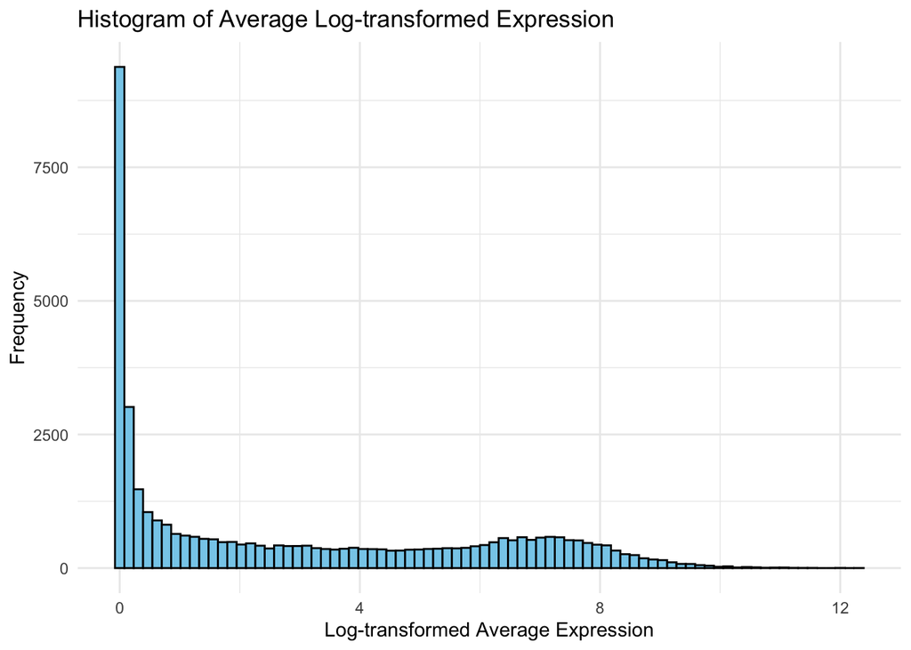

```r
library(readxl)
gene_data <- read_excel("/Users/guosa/Desktop/日常/科研/负二项分布/code/NB-EM-Algorithm/Simulation/ZINB/gene.xlsx")

# 计算每个基因在所有样本中的平均表达量
average_expression_before <- rowMeans(gene_data[, -1])

# lop1p=log(1+x)
ggplot(data.frame(Expression = log1p(average_expression_before)), aes(x = Expression)) +
    geom_histogram(bins = 80, fill = "skyblue", color = "black") +
    theme_minimal() +
    ggtitle("Histogram of Average Log-transformed Expression") +
    xlab("Log-transformed Average Expression") +
    ylab("Frequency")
```

过滤前的数据：

低表达基因数量：位于较低的对数转换后的表达量区域，直方图显示了一个非常高的峰。这表明在对数转换前有大量的基因表达值非常接近于零或是很低。这是RNA-seq数据中常见的特点，其中很多基因可能在特定的条件或样本中不被表达。

长尾分布：数据分布呈现长尾特性，随着表达量的增加，基因的数量急剧减少。直方图的尾部延伸至较高的表达值，表明存在一些高表达基因。

```r
# 过滤掉低表达基因
keep <- rowSums(gene_data[, -1] >= 5) >= 2 # 至少在两个样本中有5个以上的计数
filtered_data <- gene_data[keep, ]

# 输出过滤后的结果
cat("Number of genes before filtering:", nrow(gene_data), "\n")
```

```
## Number of genes before filtering: 39376
```

```r
cat("Number of genes after filtering:", nrow(filtered_data), "\n")
```

```
## Number of genes after filtering: 23661
```

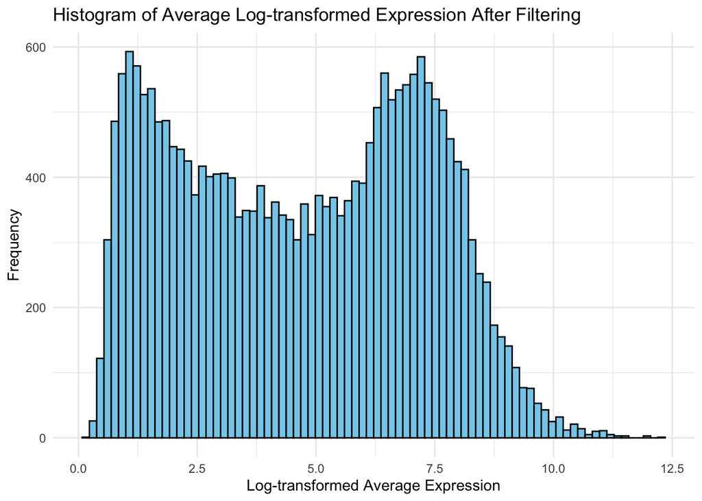

```r
average_expression_after <- rowMeans(filtered_data[, -1])

# 绘制过滤后直方图
ggplot(data.frame(Expression = log1p(average_expression_after)), aes(x = Expression)) +
    geom_histogram(bins = 80, fill = "skyblue", color = "black") +
    theme_minimal() +
    ggtitle("Histogram of Average Log-transformed Expression After Filtering") +
    xlab("Log-transformed Average Expression") +
    ylab("Frequency")
```

过滤后的数据：

减少的低表达基因数量：过滤后的直方图中低表达量的峰显著降低，说明过滤过程有效地移除了大量的低表达基因。

去除了噪声：由于过滤掉了低表达的基因，剩下的数据更可能反映了生物学上有意义的表达模式。